# Final Project 2023

2023-04-23

```r
library(tidyverse)
library(knitr)
library(readxl)# use to import .xlsx files
library(ggplot2)
library(ggrepel)
library(GGally)
library(leaflet)
library(sf)
library(RColorBrewer)
```

#### Load the dataset, covid-regions.csv dataset.

```r
regions<-read_csv("./covid-regions.csv")

head(regions)
```

```
## # A tibble: 6 × 19
##    ...1 date                state region_code region   lat  long hospi…¹ inten…²
##   <dbl> <dttm>              <chr>       <dbl> <chr>  <dbl> <dbl>   <dbl>   <dbl>
## 1     1 2020-05-03 17:00:00 ITA            13 Abruz…  42.4  13.4     300      16
## 2     2 2020-05-03 17:00:00 ITA            17 Basil…  40.6  15.8      48       3
## 3     3 2020-05-03 17:00:00 ITA             4 P.A. …  46.5  11.4     109      11
## 4     4 2020-05-03 17:00:00 ITA            18 Calab…  38.9  16.6      95       4
## 5     5 2020-05-03 17:00:00 ITA            15 Campa…  40.8  14.3     455      30
## 6     6 2020-05-03 17:00:00 ITA             8 Emili…  44.5  11.3    1997     197
## # … with 10 more variables: total_hospitalized <dbl>, home_quarantine <dbl>,
## #   total_confirmed_cases <dbl>, variation_total_confirmed <dbl>,
## #   new_confirmed_cases <dbl>, recovered <dbl>, deaths <dbl>,
## #   total_cases <dbl>, swabs_made <dbl>, casi_testati <dbl>, and abbreviated
## #   variable names ¹hospitalized_with_symptoms, ²intensive_care
```

#### Problem 1

Each group member should create one meaningful question and answer those questions using any descriptive data analysis methods.(Ex:If your group has 4 members, you should have 4 questions)

##### Name of the group member who completed this task: Justin Bennet

What are the 5 descriptive statistics of the total deaths from covid?

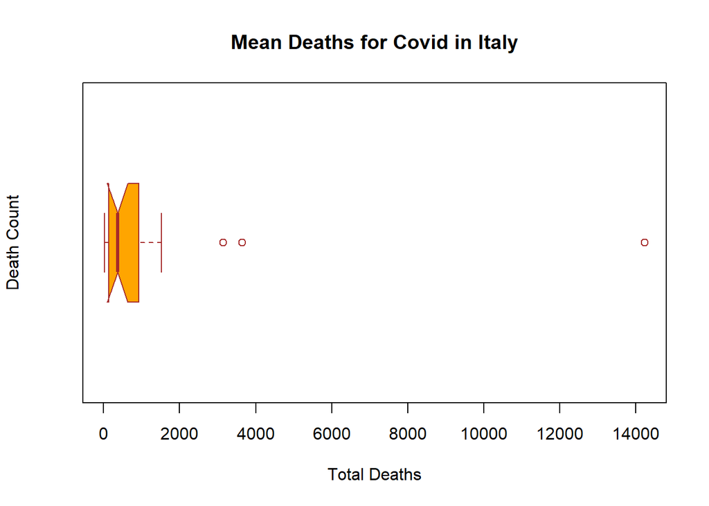

```r
boxplot(regions$deaths,
main = "Mean Deaths for Covid in Italy",
xlab = "Total Deaths",
ylab = "Death Count",
col = "orange",
border = "brown",
horizontal = TRUE,
notch = TRUE
)
```

#### Problem 2

Use “Circles” option in leaflet package to visualize the Total number of cases. Label the circles by region (Check Module 10 geospatial data visualization)

```r
n2<-leaflet(regions) %>% addTiles() %>% addCircles(lng = ~long, lat = ~lat, weight = 1,
    radius = ~total_cases, popup = ~region)

n2
```

[interactive chart not shown]

#### Problem 3 (Part1)

Create a parallel plot as given in the project instruction.

Hint: you can use ggplot, GGally, and ggrepel packages

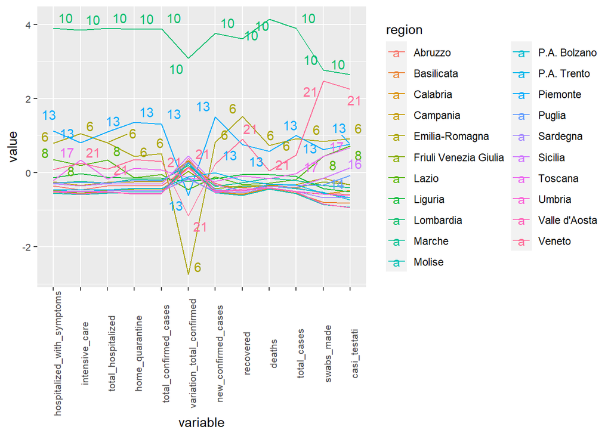

```r
ggparcoord(data=regions,
           columns=8:19,
           groupColumn="region") +
  theme(axis.text.x=element_text(angle=90),axis.text = element_text(size = 8)) +
  geom_point(size=NA)+geom_text_repel(aes(label=`...1`))
```

#### Problem 3 (Part2)

Using above plot identify any regions(four regions) which shows deviation from the rest of the regions. Extract the information about those regions. (create a new dataframe, you will use it in next question)

```r
# for some reason it would not allow a collection of length 4, I had to separate like this

newRegions = regions %>% filter(`region` == c("Piemonte", "Lombardia"))
newRegions2 = regions %>% filter(`region` == c("Veneto", "Emilia-Romagna"))
newRegions = bind_rows(newRegions, newRegions2)
```

#### Problem 3 (Part3)

Use appropriate markers in the leaflet package to visualize the above identified regions on a map. Label the markers with the region name.

```r
n3<-leaflet(newRegions) %>% addTiles() %>% addMarkers(~long, ~lat,  label = ~region)

n3
```

[interactive chart not shown]

#### Problem 4(Part1)

Using mutate function in tidyverse create new data column as $\mbox{death_per=(deaths/total_cases)*100}$ for each region and call it as “death_per”. Add death_per data to the regions dataset. Use mutate function in tidyverse.

```r
regions_death_per<-mutate(regions, death_per=(deaths/total_cases)*100)

summary(regions_death_per)
```

```
##       ...1         date                        state            region_code
##  Min.   : 1   Min.   :2020-05-03 17:00:00   Length:21          Min.   : 1.00
##  1st Qu.: 6   1st Qu.:2020-05-03 17:00:00   Class :character   1st Qu.: 5.00
##  Median :11   Median :2020-05-03 17:00:00   Mode  :character   Median :10.00
##  Mean   :11   Mean   :2020-05-03 17:00:00                      Mean   :10.19
##  3rd Qu.:16   3rd Qu.:2020-05-03 17:00:00                      3rd Qu.:15.00
##  Max.   :21   Max.   :2020-05-03 17:00:00                      Max.   :20.00
##     region               lat             long       hospitalized_with_symptoms
##  Length:21          Min.   :38.12   Min.   : 7.32   Min.   :   8
##  Class :character   1st Qu.:41.13   1st Qu.:11.12   1st Qu.:  95
##  Mode  :character   Median :43.62   Median :12.39   Median : 383
##                     Mean   :43.05   Mean   :12.23   Mean   : 821
##                     3rd Qu.:45.43   3rd Qu.:13.77   3rd Qu.: 627
##                     Max.   :46.50   Max.   :16.87   Max.   :6609
##  intensive_care   total_hospitalized home_quarantine total_confirmed_cases
##  Min.   :  1.00   Min.   :   9.0     Min.   :   33   Min.   :  109
##  1st Qu.: 10.00   1st Qu.: 102.0     1st Qu.:  587   1st Qu.:  689
##  Median : 29.00   Median : 412.0     Median : 1791   Median : 2203
##  Mean   : 71.48   Mean   : 892.5     Mean   : 3878   Mean   : 4770
##  3rd Qu.: 95.00   3rd Qu.: 695.0     3rd Qu.: 2944   3rd Qu.: 4385
##  Max.   :532.00   Max.   :7141.0     Max.   :29785   Max.   :36926
##  variation_total_confirmed new_confirmed_cases   recovered         deaths
##  Min.   :-278              Min.   :  0.00      Min.   :   98   Min.   :   22
##  1st Qu.: -41              1st Qu.:  6.00      1st Qu.:  795   1st Qu.:  138
##  Median : -13              Median : 25.00      Median : 1590   Median :  364
##  Mean   : -25              Mean   : 66.14      Mean   : 3888   Mean   : 1375
##  3rd Qu.:   1              3rd Qu.: 53.00      3rd Qu.: 3363   3rd Qu.:  927
##  Max.   : 259              Max.   :526.00      Max.   :26371   Max.   :14231
##   total_cases      swabs_made      casi_testati      death_per
##  Min.   :  301   Min.   :  7075   Min.   :  6046   Min.   : 4.878
##  1st Qu.: 1394   1st Qu.: 38835   1st Qu.: 24662   1st Qu.: 7.899
##  Median : 4144   Median : 64412   Median : 42281   Median : 9.668
##  Mean   :10034   Mean   :102561   Mean   : 69377   Mean   :10.152
##  3rd Qu.: 8359   3rd Qu.:150912   3rd Qu.:114354   3rd Qu.:11.491
##  Max.   :77528   Max.   :410857   Max.   :247176   Max.   :18.356
```

#### Problem 4 (Part2)

In this problem, your goal is to create a Choropleth map to visualize the Death Percentage for each region. The first steps of the data processing is given. Use the Italy_regions dataframe and complete the code.

Hint: Module 10 geospatial visualization

```r
Italy_regions <- read_sf('shapefile')

name_1=regions$region
regions$name_1<-name_1


 # combining data and shapfile
 is.element(regions$name_1, Italy_regions$name_1) %>%
  all()
```

```
## [1] FALSE
```

```r
 Italy_regions <- merge(Italy_regions, regions, by = 'name_1', all.x = F)
 head(Italy_regions)
```

```
## Simple feature collection with 6 features and 33 fields
## Geometry type: MULTIPOLYGON
## Dimension:     XY
## Bounding box:  xmin: 13.01941 ymin: 39.89581 xmax: 16.86736 ymax: 42.89574
## Geodetic CRS:  WGS 84
##       name_1 id_0 iso name_0 id_1 id_2   name_2 hasc_2 ccn_2 cca_2    type_2
## 1    Abruzzo  112 ITA  Italy    1    2 L'Aquila  IT.AQ     0    66 Provincia
## 2    Abruzzo  112 ITA  Italy    1    1   Chieti  IT.CH     0    69 Provincia
## 3    Abruzzo  112 ITA  Italy    1    3  Pescara  IT.PE     0    68 Provincia
## 4    Abruzzo  112 ITA  Italy    1    4   Teramo  IT.TE     0    67 Provincia
## 5 Basilicata  112 ITA  Italy    3   12  Potenza  IT.PZ     0    76 Provincia
## 6 Basilicata  112 ITA  Italy    3   11   Matera  IT.MT     0    77 Provincia
##   engtype_2 nl_name_2 varname_2 ...1                date state region_code
## 1  Province      <NA>    Aquila    1 2020-05-03 17:00:00   ITA          13
## 2  Province      <NA>      <NA>    1 2020-05-03 17:00:00   ITA          13
```

[output cut: 32 more lines]